# MSI Compliance Analysis

Analysis by Rachel Spicer, github:RASpicer

2017/08/05

# 1 Data Processing

This RMarkdown contains the code used for analysis for the 2017 paper **Compliance with Minimum Information Guidelines in Public Metabolomics Repositories**.

## 1.1 Functions

This section includes code for extracting only the minimal or best practice/ optional reporting standards.

```r
# Calculate the percentage compliance with the minimal reporting standards for clinical data
MinPerClin <- function(x) {
  # Calculate totals
  Totals = as.data.frame(colSums(x, na.rm = TRUE))
  # Extract only minimal reporting standards
  MinRep = c(Totals[1:7,], Totals[14:22,], Totals[42:44,], Totals[46,], Totals[48,], Totals[55,])
  # Calculate percentage
  Per = MinRep/(nrow(x)) * 100
  Per = round(Per, digits = 2)
  # Get column names
  Names = c(colnames(x[,1:7]), colnames(x[,14:22]), colnames(x[,42:44]), colnames(x[46]), colnames(x[48]), colnames(x[55]))
  MinMeta = as.data.frame(cbind(Names, Per))
  colnames(MinMeta) = c("Metadata", "Percentage")
  MinMeta$Percentage = as.numeric(as.character(MinMeta$Percentage))
  # Return percentage
  return(MinMeta)
}

# Calculate the percentage compliance with the minimal reporting standards for preclinical data
MinPerPreClin <- function(x,y) {
  # Calculate totals
  Totals = as.data.frame(colSums(x, na.rm = TRUE))
  # Extract only minimal reporting standards
  MinRep = c(Totals[1,], Totals[3:7,], Totals[14:17,], Totals[22:23,], Totals[25:30,], Totals[32:34,], Totals[36:37,], Totals[39:45,])
  # Calculate percentage
  Per = MinRep/(nrow(x)) * 100
  Per = round(Per, digits = 2)
  # Get column names
  Names = c(colnames(x[1]), colnames(x[,3:7]), colnames(x[,14:17]), colnames(x[,22:23]), colnames(x[,25:30]), colnames(x[,32:34]), colnames(x[,36:37]), colnames(x[,39:45]))
  MinMeta = as.data.frame(cbind(Names, Per))
  colnames(MinMeta) = c("Metadata", "Percentage")
  MinMeta$Percentage = as.numeric(as.character(MinMeta$Percentage))
  # Return percentage
  return(MinMeta)
}

# Calculate the percentage compliance with the minimal reporting standards for microbial/cell line data
MinPerCellLine <- function(x) {
  # Calculate totals
  Totals = as.data.frame(colSums(x, na.rm = TRUE))
  # Extract only minimal reporting standards
  MinRepSt = Totals[1:15,]
  # Calculate percentage
  Per = MinRepSt/(nrow(x)) * 100
  Per = round(Per, digits = 2)
  # Get column names
  Names = c(colnames(x[,1:15]))
  MinMeta = as.data.frame(cbind(Names, Per))
  colnames(MinMeta) = c("Metadata", "Percentage")
  MinMeta$Percentage = as.numeric(as.character(MinMeta$Percentage))
  return(MinMeta)
}

# Calculate the percentage compliance with the minimal reporting standards for plant studies
MinPerPlant <- function(x) {
  # Calculate totals
  Totals = as.data.frame(colSums(x, na.rm = TRUE))
  # Calculate percentage
  Per = Totals/(nrow(x)) * 100
  Per = round(Per, digits = 2)
  # Get column names
  Names = colnames(x)
  MinMeta = as.data.frame(cbind(Names, Per))
  colnames(MinMeta) = c("Metadata", "Percentage")
  MinMeta$Percentage = as.numeric(as.character(MinMeta$Percentage))
  # Return percentage
  return(MinMeta)
}

# Calculate the percentage compliance with the optional reporting standards for microbial/cell line data
OpPerCellLine <- function(x) {
  # Calculate totals
  Totals = as.data.frame(colSums(x, na.rm = TRUE))
  # Extract only optional reporting standards
  OpRep = Totals[16:54,]
  # Calculate percentage
  Per = OpRep/(nrow(x)) * 100
  Per = round(Per, digits = 2)
  # Get column names
  Names = c(colnames(x[,16:54]))
  OpMeta = as.data.frame(cbind(Names, Per))
  colnames(OpMeta) = c("Metadata", "Percentage")
  OpMeta$Percentage = as.numeric(as.character(OpMeta$Percentage))
  # Return percentage
  return(OpMeta)
}

# Calculate the percentage compliance with the optional reporting standards for clinical data
OpPerClin <- function(x) {
  # Calculate totals
  Totals = as.data.frame(colSums(x, na.rm = TRUE))
  OpRep = c(Totals[8:13,], Totals[23:41,], Totals[45,], Totals[47,], Totals[49:54,])
  # Calculate percentage
  Per = OpRep/(nrow(x)) * 100
  Per = round(Per, digits = 2)
  # Get column names
  Names = c(colnames(x[,8:13]), colnames(x[,23:41]), colnames(x[45]), colnames(x[47]), colnames(x[,49:54]))
  OpMeta = as.data.frame(cbind(Names, Per))
  colnames(OpMeta) = c("Metadata", "Percentage")
  OpMeta$Percentage = as.numeric(as.character(OpMeta$Percentage))
  # Return percentage
  return(OpMeta)
}

# Calculate the percentage compliance with the optional reporting standards for preclinical data
OpPerPreClin <- function(x) {
  # Calculate totals
  Totals = as.data.frame(colSums(x, na.rm = TRUE))
  # Extract only minimal reporting standards
  OpRep = c(Totals[2,], Totals[8:13,], Totals[18:21,], Totals[24,], Totals[31,], Totals[35,], Totals[38,], Totals[46,])
  # Calculate percentage
  Per = OpRep/(nrow(x)) * 100
    Per = round(Per, digits = 2)
  # Get column names
  Names = c(colnames(x[2]), colnames(x[,8:13]), colnames(x[,18:21]),colnames(x[24]), colnames(x[31]), colnames(x[35]), colnames(x[38]), colnames(x[46]))
  OpMeta = as.data.frame(cbind(Names, Per))
  colnames(OpMeta) = c("Metadata", "Percentage")
  OpMeta$Percentage = as.numeric(as.character(OpMeta$Percentage))
  # Return percentage
  return(OpMeta)
}

# ggplot theme
theme_adjbw <- function(base_size = 12, base_family = ""){
  theme_bw() +
    theme(
      axis.text = element_text(colour = "black"),
      axis.line.x = element_line(color="black", size = 0.5),
      axis.line.y = element_line(color="black", size = 0.5),
      # Remove gridlines and borders
      panel.grid.major = element_blank(),
      panel.grid.minor = element_blank(),
      panel.border = element_blank(),
      panel.background = element_blank()
    )
}
```

## 1.2 Data Processing

Data for the compliance to one of the four sets of reporting standards is first split by repository. The percentage of studies that comply with each reporting standard is then calculated. Reporting standards are then divided into minimal and best practice/optional.

```r
# read compliance data for each study type
Mouse <- read.xlsx("../MousePreclinicalRawData4Analysis.xlsx", sheetIndex = 1,
    check.names = FALSE)
Plant <- read.xlsx("../ArabidopsisPlantRawData4Analysis.xlsx", sheetIndex = 1,
    check.names = FALSE)
HumanClin <- read.xlsx("../HumanClinicalRawData4Analysis.xlsx", sheetIndex = 1,
    check.names = FALSE)
HumanCell <- read.xlsx("../HumanCellRawData4Analysis.xlsx", sheetIndex = 1,
    check.names = FALSE)

# Extract only MetaboLights studies
MLMouse <- Mouse[grep("MetaboLights", Mouse$`Study Repository `), ]
MLPlant <- Plant[grep("MetaboLights", Plant$`Study Repository `), ]
MLHumanClin <- HumanClin[grep("MetaboLights", HumanClin$`Study Repository`),
    ]
MLHumanCell <- HumanCell[grep("MetaboLights", HumanCell$`Study Repository `),
    ]

# Extract only Metabolomics Workbench studies
MWMouse <- Mouse[grep("Metabolomics Workbench", Mouse$`Study Repository `),
    ]
MWPlant <- Plant[grep("Metabolomics Workbench", Plant$`Study Repository `),
    ]
MWHumanClin <- HumanClin[grep("Metabolomics Workbench", HumanClin$`Study Repository`),
    ]
MWHumanCell <- HumanCell[grep("Metabolomics Workbench", HumanCell$`Study Repository `),
    ]

# Extract only MetaPhen studies
MPPlant <- Plant[grep("MetaPhen", Plant$`Study Repository `), ]

# Extract only MeRy-B studies
MeRPlant <- Plant[grep("MeRy-B", Plant$`Study Repository `), ]

# Minimal - MetaboLights
MLHumanCellP <- MinPerCellLine(MLHumanCell[, -(1:2)])
MLHumanCellP$Order <- rep(1)
MLHumanClinP <- MinPerClin(MLHumanClin[, -(1:2)])
MLHumanClinP$Order <- rep(2)
MLMouseP <- MinPerPreClin(MLMouse[, -(1:2)])
MLMouseP$Order <- rep(3)
MLPlantP <- MinPerPlant(MLPlant[, -(1:2)])
MLPlantP$Order <- rep(4)

# Minimal - Metabolomics Workbench
MWHumanCellP <- MinPerCellLine(MWHumanCell[, -(1:2)])
MWHumanCellP$Order <- rep(1)
MWHumanClinP <- MinPerClin(MWHumanClin[, -(1:2)])
MWHumanClinP$Order <- rep(2)
MWMouseP <- MinPerPreClin(MWMouse[, -(1:2)])
MWMouseP$Order <- rep(3)
MWPlantP <- MinPerPlant(MWPlant[, -(1:2)])
MWPlantP$Order <- rep(4)

# Minimal - MetaPhen
MPPlantP <- MinPerPlant(MPPlant[, -(1:2)])
MPPlantP$Order <- rep(1)

# Minimal - MeRy-B
MeRPlantP <- MinPerPlant(MeRPlant[, -(1:2)])
MeRPlantP$Order <- rep(4)

# Best Practice - MetaboLights
MLHumanCellOP <- OpPerCellLine(MLHumanCell[, -(1:2)])
MLHumanCellOP$Order <- rep(1)
MLHumanClinOP <- OpPerClin(MLHumanClin[, -(1:2)])
MLHumanClinOP$Order <- rep(2)
MLMouseOP <- OpPerPreClin(MLMouse[, -(1:2)])
MLMouseOP$Order <- rep(3)

# Best Practice - Metabolomics Workbench
MWHumanCellOP <- OpPerCellLine(MWHumanCell[, -(1:2)])
MWHumanCellOP$Order <- rep(1)
MWHumanClinOP <- OpPerClin(MWHumanClin[, -(1:2)])
MWHumanClinOP$Order <- rep(2)
MWMouseOP <- OpPerPreClin(MWMouse[, -(1:2)])
MWMouseOP$Order <- rep(3)
```

# 2 Figures

Code that was used to generate the raw figures from the paper. The raw figures were then edited in Adobe Illustrator to add letters to indicate statistical significance and to change colours to patterns in figure 2.

## 2.1 Figure 1a. Compliance to Minimal MSI Reporting Standards in MetaboLights

Combined box-and-whisker and dot plot showing the percentage compliance with the MSI minimum reporting standards within the MetaboLights repository. and b) Metabolomics Workbench repositories. Each “dot” represents compliance to a single reporting standard.

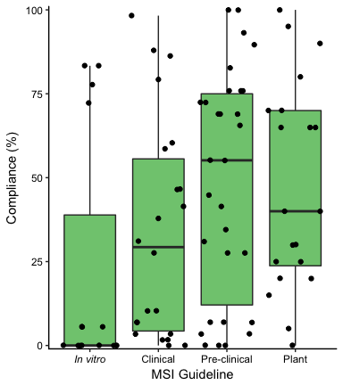

```r
ML <- rbind(MLHumanCellP, MLHumanClinP, MLMouseP, MLPlantP)
ML$Order <- as.factor(ML$Order)
ggplot(ML, aes(x = Order, y = Percentage)) + geom_boxplot(fill = "#7fc97f",
    outlier.shape = 3, outlier.color = "red") + geom_jitter() + scale_x_discrete(labels = c(expression(italic("In vitro")),
    "Clinical", "Pre-clinical", "Plant")) + scale_y_continuous(expand = c(0,
    0), limits = c(-1, 101)) + theme_adjbw() + xlab("MSI Guideline") + ylab("Compliance (%)")
```

## 2.2 Figure 1b. Compliance to Minimal MSI Reporting Standards in Metabolomics Workbench

Combined box-and-whisker and dot plot showing the percentage compliance with the MSI minimum reporting standards within the Metabolomics Workbench repository. Red ‘+’ indicate outliers, each “dot” represents compliance to a single reporting standard.

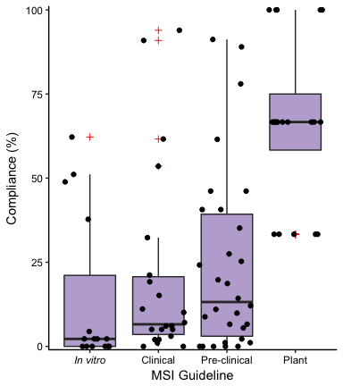

```r
MW <- rbind(MWHumanCellP, MWHumanClinP, MWMouseP, MWPlantP)
MW$Order <- as.factor(MW$Order)
ggplot(MW, aes(x = Order, y = Percentage)) + geom_boxplot(fill = "#beaed4",
    outlier.shape = 3, outlier.color = "red") + geom_jitter() + scale_x_discrete(labels = c(expression(italic("In vitro")),
    "Clinical", "Pre-clinical", "Plant")) + theme_adjbw() + scale_y_continuous(expand = c(0,
    0), limits = c(-1, 101)) + xlab("MSI Guideline") + ylab("Compliance (%)")
```

## 2.3 Figure 2a. Comparison of Compliance to Minimal and Best Practice Reporting Standards in MetaboLights

Box-and-whisker plot showing the percentage compliance to the minimal and optional/best practice reporting standards in MetaboLights. Minimal reporting standards are indicated in green, optional/best practice reporting standards are blue and red ‘+’ indicate outliers.

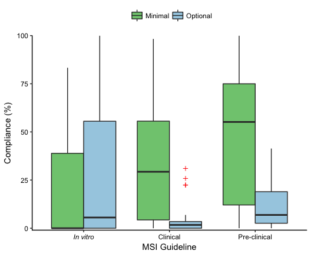

```r
# Compare minimal and optional reporting standards within databases
# MetaboLights
MLMin <- rbind(MLHumanCellP, MLHumanClinP, MLMouseP)
MLO <- rbind(MLHumanCellOP, MLHumanClinOP, MLMouseOP)
MLMin$Req <- rep("Minimal")
MLO$Req <- rep("Optional")
MLComp <- rbind(MLMin, MLO)
MLComp$Order <- as.factor(MLComp$Order)
# Plot box and Whisker diagram
ggplot(MLComp, aes(x=Order, y=Percentage, fill = Req))  +
  geom_boxplot(outlier.shape = 3, outlier.color = "red")  +
  scale_x_discrete(labels = c(expression(italic("In vitro")),
                              "Clinical",
                              "Pre-clinical",
                              "Plant")) +
  theme_bw() +
  theme(
    axis.text = element_text(colour = "black"),
    axis.line.x = element_line(color="black", size = 0.5),
    axis.line.y = element_line(color="black", size = 0.5),
    # Remove gridlines and borders
    panel.grid.major = element_blank(),
    panel.grid.minor = element_blank(),
    panel.border = element_blank(),
    panel.background = element_blank(),
    legend.title = element_blank(),
    legend.position="top") +
  scale_y_continuous(expand = c(0, 0), limits = c(-1, 100)) +
  xlab("MSI Guideline") +
  ylab("Compliance (%)") +
  scale_fill_manual(values = c("#7fc97f", "#a6cee3"))
```

## 2.4 Figure 2b.Comparison of Compliance to Minimal and Best Practice Reporting Standards in Metabolomics Workbench

Box-and-whisker plot showing the percentage compliance to the minimal and optional/best practice reporting standards in Metabolomics Workbench. Minimal reporting standards are indicated in purple, optional/best practice reporting standards are pink and red ‘+’ indicate outliers.

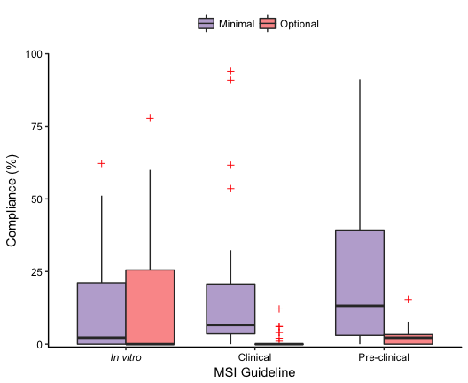

```r
# Compare minimal and optional reporting standards within databases
# MetaboLights
MWMin <- rbind(MWHumanCellP, MWHumanClinP, MWMouseP)
MWO <- rbind(MWHumanCellOP, MWHumanClinOP, MWMouseOP)
MWMin$Req <- rep("Minimal")
MWO$Req <- rep("Optional")
MWComp <- rbind(MWMin, MWO)
MWComp$Order <- as.factor(MWComp$Order)
# Plot box and Whisker diagram
ggplot(MWComp, aes(x=Order, y=Percentage, fill = Req))  +
  geom_boxplot(outlier.shape = 3, outlier.color = "red")  +
  scale_x_discrete(labels = c(expression(italic("In vitro")),
                              "Clinical",
                              "Pre-clinical",
                              "Plant")) +
  theme_bw() +
  theme(
    axis.text = element_text(colour = "black"),
    axis.line.x = element_line(color="black", size = 0.5),
    axis.line.y = element_line(color="black", size = 0.5),
    # Remove gridlines and borders
    panel.grid.major = element_blank(),
    panel.grid.minor = element_blank(),
    panel.border = element_blank(),
    panel.background = element_blank(),
    legend.title = element_blank(),
    legend.position="top") +
  scale_y_continuous(expand = c(0, 0), limits = c(-1, 100)) +
  xlab("MSI Guideline") +
  ylab("Compliance (%)") +
  scale_fill_manual(values = c("#beaed4", "#fb9a99"))
```

## 2.5 Figure 3. Compliance to Plant MSI Reporting Standards.

Combined box-and-whisker and dot plots showing the percentage compliance of *A. thaliana* studies to the plant MSI minimum reporting standards within the MeRy-B, MetaboLights, Metabolomics Workbench and MetaPhen repositories. Red ‘+’ indicate outliers; each “dot” represents compliance to a single reporting standard. Letters denote significant differences in compliance (Kruskal Wallis, Dunn post-hoc test with Benjamini-Hochberg correction).

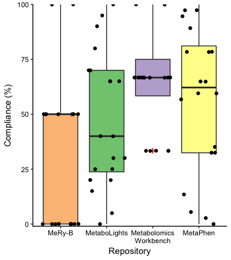

```r
MLPlantP$Repository <- rep("MetaboLights")
MWPlantP$Repository <- rep("Metabolomics Workbench")
MPPlantP$Repository <- rep("MetaPhen")
MeRPlantP$Repository <- rep("MeRy-B")
Plant <- rbind(MLPlantP, MWPlantP, MPPlantP, MeRPlantP)
Plant$Repository <- as.factor(Plant$Repository)
levels(Plant$Repository) <- gsub(" ", "\n", levels(Plant$Repository))
ggplot(Plant, aes(x=Repository, y=Percentage, fill=Repository))  +
  geom_boxplot(outlier.shape = 3, outlier.color = "red")  +
  geom_jitter() +
  theme_bw() +
  theme(
    axis.text = element_text(colour = "black"),
    axis.line.x = element_line(color="black", size = 0.5),
    axis.line.y = element_line(color="black", size = 0.5),
    # Remove gridlines and borders
    panel.grid.major = element_blank(),
    panel.grid.minor = element_blank(),
    panel.border = element_blank(),
    panel.background = element_blank(),
    legend.position="none") +
  scale_y_continuous(expand = c(0, 0), limits = c(-1, 100)) +
  ylab("Compliance (%)") +
  scale_fill_manual(values = c("#fdc086","#7fc97f", "#beaed4", "#ffff99"))
```

## 2.6 Supplementary Figure 1a. Compliance to Best Practice MSI Reporting Standards in MetaboLights

Combined box-and-whisker and dot plot showing the percentage compliance with the MSI best practice/optional reporting standards within the MetaboLights repository. Red `+’ indicate outliers.

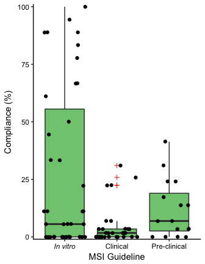

```r
MLO <- rbind(MLHumanCellOP, MLHumanClinOP, MLMouseOP)
MLO$Order <- as.factor(MLO$Order)
ggplot(MLO, aes(x = Order, y = Percentage)) + geom_boxplot(fill = "#7fc97f",
    outlier.shape = 3, outlier.color = "red") + geom_jitter() + scale_x_discrete(labels = c(expression(italic("In vitro")),
    "Clinical", "Pre-clinical", "Plant")) + scale_y_continuous(expand = c(0,
    0), limits = c(-1, 101)) + theme_adjbw() + xlab("MSI Guideline") + ylab("Compliance (%)")
```

## 2.7 Supplementary Figure 1b. Compliance to Best Practice MSI Reporting Standards in Metabolomics Workbench

Combined box-and-whisker and dot plot showing the percentage compliance with the MSI best practice/optional reporting standards within the Metabolomics Workbench Repository. Red `+’ indicate outliers.

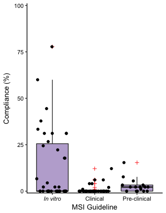

```r
MWO <- rbind(MWHumanCellOP, MWHumanClinOP, MWMouseOP)
MWO$Order <- as.factor(MWO$Order)
ggplot(MWO, aes(x = Order, y = Percentage)) + geom_boxplot(fill = "#beaed4",
    outlier.shape = 3, outlier.color = "red") + geom_jitter() + scale_x_discrete(labels = c(expression(italic("In vitro")),
    "Clinical", "Pre-clinical", "Plant")) + theme_adjbw() + scale_y_continuous(expand = c(0,
    0), limits = c(-1, 101)) + xlab("MSI Guideline") + ylab("Compliance (%)")
```

## 2.8 Supplementary Figure 2. Species per Repository

The frequency of studies including different species in the metabolomics data repositories: MeRy-B, MetaboLights, Metabolomics Workbench and MetaPhen. For a species to be plotted as an individual band it must have been found in a minimum of nine studies across the repositories. Species found in less than nine studies across the four repositories are reported as Other Species.

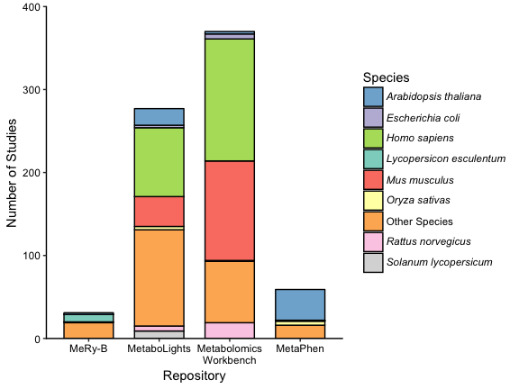

```r
# Load csv
SpeciesbyRepository <- read.csv("../SpeciesperRepository.csv")
# Replace all spaces with line graps for a cleaner plot
levels(SpeciesbyRepository$Repository) <- gsub(" ", "\n", levels(SpeciesbyRepository$Repository))
ggplot(SpeciesbyRepository, aes(x=Repository, y=Frequency, fill=Species))  +
  geom_bar(colour="black", stat="identity", width = 0.7) +
  scale_y_continuous(expand = c(0, 0), limits = c(0, 400)) +
  scale_fill_manual(values = c('#80b1d3','#bebada','#b3de69',"#8dd3c7",
                                          '#fb8072',
                                          '#ffffb3',
                                          '#fdb462',
                                          '#fccde5',
                                          '#d9d9d9'),
                               labels = c(expression(italic("Arabidopsis thaliana")),
                                          expression(italic("Escherichia coli")),
                                          expression(italic("Homo sapiens")),
                                          expression(italic("Lycopersicon esculentum")),
                                          expression(italic("Mus musculus")),
                                          expression(italic("Oryza sativas")),
                                          "Other Species",
                                          expression(italic("Rattus norvegicus")),
                                          expression(italic("Solanum lycopersicum"))))  +
  ylab("Number of Studies") +
  theme_bw() +
  theme(axis.text = element_text(colour = "black"),
        legend.text.align = 0,
        #legend.text = element_text(face = "italic"),
        axis.line.x = element_line(color="black", size = 0.5),
        axis.line.y = element_line(color="black", size = 0.5),
        panel.grid.major = element_blank(),
        panel.grid.minor = element_blank(),
        panel.border = element_blank(),
        panel.background = element_blank())
```

# 3 Statistical Analysis

For analysing differences within repositories (ML and MW) Kruskal Wallis tests, followed by Dunn post-hoc tests with Benjamini-Hochberg correction were used. A Kruskal Wallis test was also used for comparing differences between repositories, both between ML and MW and between all four repositories for the plant guidelines. Mann-Whitney U tests were used to analyse difference between minimal and best practice reporting standards.

```r
# Between MetaboLights minimal
KruskalML <- kruskal.test(Percentage ~ Order, data = ML)
DunnML <- dunnTest(Percentage ~ Order, data = ML, method = "bh")

# Between Metabolomics Workbench minimal
KruskalMW <- kruskal.test(Percentage ~ Order, data = MW)
DunnMW <- dunnTest(Percentage ~ Order, data = MW, method = "bh")

# Between MetaboLights best practice/optional
KruskalMLO <- kruskal.test(Percentage ~ Order, data = MLO)
DunnMLO <- dunnTest(Percentage ~ Order, data = MLO, method = "bh")

# Between Metabolomics Workbench best practice/optional
KruskalMWO <- kruskal.test(Percentage ~ Order, data = MWO)
DunnMWO <- dunnTest(Percentage ~ Order, data = MWO, method = "bh")

# Between repositories for plant guidelines only Add repostitory to plant
# data
KruskalPlant <- kruskal.test(Percentage ~ Repository, data = Plant)
DunnPlant <- dunnTest(Percentage ~ Repository, data = Plant, method = "bh")

# Compare Between repositories - MetaboLights and Metabolomics Workbench
# Kruskal Wallis - Minimal
ML$Repository <- rep("MetaboLights")
MW$Repository <- rep("Metablomics Workbench")
MLMW <- rbind(ML, MW)
MLMW$Repository <- as.factor(MLMW$Repository)
KruskalMLMW <- kruskal.test(Percentage ~ Repository, data = MLMW)

# Kruskal Wallis - Optional
MLO$Repository <- rep("MetaboLights")
MWO$Repository <- rep("Metablomics Workbench")
MLMWO <- rbind(MLO, MWO)
MLMWO$Repository <- as.factor(MLMWO$Repository)
KruskalMLMWO <- kruskal.test(Percentage ~ Repository, data = MLMWO)

# Between Minimum and Optional MetaboLights Human - Cell Line
MLHumanCellP$MinBP <- rep("Min")
MLHumanCellOP$MinBP <- rep("BP")
MLHumanCellCom <- rbind(MLHumanCellP, MLHumanCellOP)
MLHumanCellCom$MinBP <- as.factor(MLHumanCellCom$MinBP)
MannWhitMLHumanCell <- wilcox.test(Percentage ~ MinBP, data = MLHumanCellCom)
# Human - Clinical
MLHumanClinP$MinBP <- rep("Min")
MLHumanClinOP$MinBP <- rep("BP")
MLHumanClinCom <- rbind(MLHumanClinP, MLHumanClinOP)
MLHumanClinCom$MinBP <- as.factor(MLHumanClinCom$MinBP)
MannWhitMLHumanClin <- wilcox.test(Percentage ~ MinBP, data = MLHumanClinCom)
# Mouse - Pre-clinical
MLMouseP$MinBP <- rep("Min")
MLMouseOP$MinBP <- rep("BP")
MLMouseCom <- rbind(MLMouseP, MLMouseOP)
MLMouseCom$MinBP <- as.factor(MLMouseCom$MinBP)
MannWhitMLMouse <- wilcox.test(Percentage ~ MinBP, data = MLMouseCom)

# Metabolomics Workbench Human - Cell Line
MWHumanCellP$MinBP <- rep("Min")
MWHumanCellOP$MinBP <- rep("BP")
MWHumanCellCom <- rbind(MWHumanCellP, MWHumanCellOP)
MWHumanCellCom$MinBP <- as.factor(MWHumanCellCom$MinBP)
MannWhitMWHumanCell <- wilcox.test(Percentage ~ MinBP, data = MWHumanCellCom)
# Human - Clinical
MWHumanClinP$MinBP <- rep("Min")
MWHumanClinOP$MinBP <- rep("BP")
MWHumanClinCom <- rbind(MWHumanClinP, MWHumanClinOP)
MWHumanClinCom$MinBP <- as.factor(MWHumanClinCom$MinBP)
MannWhitMWHumanClin <- wilcox.test(Percentage ~ MinBP, data = MWHumanClinCom)
# Mouse - Pre-clinical
MWMouseP$MinBP <- rep("Min")
MWMouseOP$MinBP <- rep("BP")
MWMouseCom <- rbind(MWMouseP, MWMouseOP)
MWMouseCom$MinBP <- as.factor(MWMouseCom$MinBP)
MannWhitMWMouse <- wilcox.test(Percentage ~ MinBP, data = MWMouseCom)
```

# 4 Supplementary Tables

## 4.1 Supplementary Table 1. Compliance of Human Clinical Studies to Minimal MSI Reporting Standards

```r
HumanClinP <- cbind(MLHumanClinP[, 1:2], MWHumanClinP[, 2])
rownames(HumanClinP) <- HumanClinP$Metadata
colnames(HumanClinP) <- c("Metadata", "MetaboLights", "Metabolomics Workbench")
HumanClinP$total <- rowSums(HumanClinP[2:3])
HumanClinP <- HumanClinP[order(-HumanClinP$total), ]
kable(HumanClinP[, 2:3], caption = "The percentage of *Homo sapiens* studies in each repository that comply with each mammalian clinical trials and human studies minimal reporting standard. ")
```

The percentage of *Homo sapiens* studies in each repository that comply with each mammalian clinical trials and human studies minimal reporting standard.

|  | MetaboLights | Metabolomics Workbench |
| --- | --- | --- |
| Biofluid or Tissue | 98.28 | 90.91 |
| Number of Groups | 86.21 | 93.94 |
| Disease Status | 60.34 | 61.62 |
| Sample Storage Temperature | 58.62 | 53.54 |
| Ethical Approval | 87.93 | 15.15 |
| Age Range | 79.31 | 19.19 |
| Weight range and Height and/or BMI | 46.55 | 32.32 |
| Fasting Status | 31.03 | 21.21 |
| Gender | 46.55 | 3.03 |
| Inclusion Criteria | 41.38 | 5.05 |
| Exclusion Criteria | 37.93 | 7.07 |
| Volume or Quantity of Collection | 27.59 | 5.05 |
| Anticoagulant | 10.34 | 10.10 |
| Treatment | 3.45 | 11.11 |
| Ethnicity | 6.90 | 6.06 |
| Trial Type | 10.34 | 1.01 |
| Treatment Dose | 3.45 | 6.06 |
| Location of Collection | 6.90 | 2.02 |
| Treatment Duration | 1.72 | 5.05 |
| Treatment Route | 1.72 | 2.02 |
| Treatment Vehicle | 0.00 | 0.00 |
| Bacteriostatic Agent | 0.00 | 0.00 |

## 4.2 Supplementary Table 2. Compliance of Human Cell Line Studies to Minimal MSI Reporting Standards

```r
HumanCellP <- cbind(MLHumanCellP[, 1:2], MWHumanCellP[, 2])
rownames(HumanCellP) <- HumanCellP$Metadata
colnames(HumanCellP) <- c("Metadata", "MetaboLights", "Metabolomics Workbench")
HumanCellP$total <- rowSums(HumanCellP[2:3])
HumanCellP <- HumanCellP[order(-HumanCellP$total), ]
kable(HumanCellP[, 2:3], caption = "The percentage of *Homo sapiens* studies in each repository that comply with each microbial and *in vitro* minimal reporting standard.")
```

The percentage of *Homo sapiens* studies in each repository that comply with each microbial and *in vitro* minimal reporting standard.

|  | MetaboLights | Metabolomics Workbench |
| --- | --- | --- |
| Metabolism Quenching Method | 83.33 | 62.22 |
| Harvesting Method | 83.33 | 48.89 |
| Metabolite Extraction | 77.78 | 51.11 |
| Sample Storage | 72.22 | 37.78 |
| Normalisation by Cell Number | 5.56 | 2.22 |
| Cell Integrity | 5.56 | 0.00 |
| Stability | 5.56 | 0.00 |
| Temperature from Sampling to Quenching | 0.00 | 4.44 |
| Time Until Quenching | 0.00 | 2.22 |
| Extracellular Metabolites Discriminated | 0.00 | 2.22 |
| Recovery from Extraction | 0.00 | 2.22 |
| Sample Clean-up | 0.00 | 0.00 |
| Sample Storage Duration | 0.00 | 0.00 |
| Quality Control | 0.00 | 0.00 |
| Detection Limit | 0.00 | 0.00 |

## 4.3 Supplementary Table 3. Compliance of Mouse Pre-Clinical Studies to Minimal MSI Reporting Standards

```r
MouseP <- cbind(MLMouseP[, 1:2], MWMouseP[, 2])
rownames(MouseP) <- MouseP$Metadata
colnames(MouseP) <- c("Metadata", "MetaboLights", "Metabolomics Workbench")
MouseP$total <- rowSums(MouseP[2:3])
MouseP <- MouseP[order(-MouseP$total), ]
kable(MouseP[, 2:3], caption = "The percentage of *Mus musculus* studies in each repository that comply with each pre-clinical minimal reporting standard.")
```

The percentage of *Mus musculus* studies in each repository that comply with each pre-clinical minimal reporting standard.

|  | MetaboLights | Metabolomics Workbench |
| --- | --- | --- |
| Biofluid or Tissue | 100.00 | 89.01 |
| Number of Groups | 75.86 | 91.21 |
| Strain | 100.00 | 61.54 |
| Treatment | 75.86 | 78.02 |
| Sex | 93.10 | 46.15 |
| Collection Time | 89.66 | 40.66 |
| Age at Collection or Euthanization | 68.97 | 46.15 |
| Sample Storage Temperature | 65.52 | 35.16 |
| Age at Study Start | 75.86 | 24.18 |
| Treatment Duration | 72.41 | 27.47 |
| Animal Supplier | 82.76 | 10.99 |
| Treatment Dose | 72.41 | 19.78 |
| Diet | 44.83 | 40.66 |
| Treatment Route | 68.97 | 14.29 |
| ab lib or Restricted Diet | 68.97 | 6.59 |
| Light Cycle | 55.17 | 9.89 |
| Treatment Vehicle | 55.17 | 6.59 |
| Euthanasia Method | 41.38 | 18.68 |
| Tissue Processing | 27.59 | 25.27 |
| Group or Individual Housing | 31.03 | 5.49 |
| Fasting Status | 27.59 | 8.79 |
| Weight Range | 34.48 | 0.00 |
| Volume or Quantity of Sample Collection | 6.90 | 12.09 |
| Tap or Purified Water | 6.90 | 0.00 |
| Anticoagulant | 6.90 | 0.00 |
| Collection Method | 3.45 | 1.10 |
| Collection Frequency | 3.45 | 1.10 |
| Location of Sample Collection | 0.00 | 2.20 |
| Collection Duration | 0.00 | 0.00 |
| Bacteriostatic Agent | 0.00 | 0.00 |

## 4.4 Supplementary Table 4. Compliance of Arabidopis Studies to Minimal MSI Reporting Standards

```r
PlantP <- cbind(MeRPlantP[, 1:2], MLPlantP[, 2], MWPlantP[, 2], MPPlantP[, 2])
colnames(PlantP) <- c("Metadata", "MeRy-B", "MetaboLights", "Metabolomics Workbench",
    "MetaPhen")
PlantP$total <- rowSums(PlantP[2:5])
PlantP <- PlantP[order(-PlantP$total), ]
kable(PlantP[, 2:5], caption = "The percentage of *Arabidopsis thaliana* studies in each repository that comply with each plant minimal reporting standard.")
```

The percentage of *Arabidopsis thaliana* studies in each repository that comply with each plant minimal reporting standard.

|  | MeRy-B | MetaboLights | Metabolomics Workbench | MetaPhen |
| --- | --- | --- | --- | --- |
| Organ or Cell Type | 100 | 100 | 100.00 | 94.59 |
| Plant Growth Stage | 100 | 65 | 100.00 | 78.38 |
| Genotype | 100 | 70 | 66.67 | 100.00 |
| Growth Support | 50 | 95 | 66.67 | 97.30 |
| Light | 50 | 90 | 66.67 | 97.30 |
| Metabolism Quenching Method | 100 | 30 | 100.00 | 64.86 |
| Date(s) of Plant Establishment | 50 | 80 | 66.67 | 89.19 |
| Temperature | 50 | 70 | 66.67 | 78.38 |
| Harvest Time, Date | 0 | 65 | 100.00 | 78.38 |
| Nutrients Regime | 50 | 40 | 66.67 | 64.86 |
| Harvest Method | 50 | 30 | 100.00 | 35.14 |
| Biosource Amount | 50 | 65 | 66.67 | 13.51 |
| Sample Storage | 50 | 40 | 66.67 | 32.43 |
| Humidity | 0 | 20 | 66.67 | 32.43 |
| Treatment | 0 | 25 | 33.33 | 59.46 |
| Treatment Time | 0 | 25 | 33.33 | 56.76 |
| Treatment Dose | 0 | 20 | 33.33 | 59.46 |
| Plot Design | 0 | 5 | 66.67 | 5.41 |
| Growth Location | 0 | 15 | 33.33 | 0.00 |
| Watering Regime | 0 | 0 | 33.33 | 2.70 |

## 4.5 Supplementary Table 5. Compliance of Human Clinical Studies to Best Practice MSI Reporting Standards

```r
HumanClinOP <- cbind(MLHumanClinOP[, 1:2], MWHumanClinOP[, 2])
rownames(HumanClinOP) <- HumanClinOP$Metadata
colnames(HumanClinOP) <- c("Metadata", "MetaboLights", "Metabolomics Workbench")
HumanClinOP$total <- rowSums(HumanClinOP[2:3])
HumanClinOP <- HumanClinOP[order(-HumanClinOP$total), ]
kable(HumanClinOP[, 2:3], caption = "The percentage of *Homo sapiens* studies in each repository that comply with each mammalian clinical trials and human studies optional reporting standard.")
```

The percentage of *Homo sapiens* studies in each repository that comply with each mammalian clinical trials and human studies optional reporting standard.

|  | MetaboLights | Metabolomics Workbench |
| --- | --- | --- |
| Arterial or Venous Blood | 31.03 | 4.04 |
| Speed of Centrifugation | 25.86 | 6.06 |
| Temperature of Centrifugation | 22.41 | 6.06 |
| Time of Centrifugation | 22.41 | 4.04 |
| Smoking Status | 6.90 | 12.12 |
| Time from Collection to Freezing | 6.90 | 2.02 |
| Drug Consumption | 3.45 | 1.01 |
| Alcohol Consumption | 3.45 | 0.00 |
| Hemoglobin | 3.45 | 0.00 |
| Platelets | 3.45 | 0.00 |
| White Blood Count | 3.45 | 0.00 |
| Diet | 1.72 | 0.00 |
| Malnutrition | 1.72 | 0.00 |
| Creatinine | 1.72 | 0.00 |
| Hemocrit | 1.72 | 0.00 |
| Sodium | 1.72 | 0.00 |
| Potassium | 1.72 | 0.00 |
| Sample Storage Duration | 1.72 | 0.00 |
| Mid Flow or Total Urine | 1.72 | 0.00 |
| Metal Exposure | 0.00 | 0.00 |
| Urea | 0.00 | 0.00 |
| Glucose | 0.00 | 0.00 |
| Total Cholesterol | 0.00 | 0.00 |
| HDL Cholesterol | 0.00 | 0.00 |
| LDL Cholesterol | 0.00 | 0.00 |
| Triglycerides | 0.00 | 0.00 |
| Total Protein | 0.00 | 0.00 |
| Albumin | 0.00 | 0.00 |
| Bilirubin | 0.00 | 0.00 |
| ALT | 0.00 | 0.00 |
| ALP | 0.00 | 0.00 |
| GT | 0.00 | 0.00 |
| Hemolysis | 0.00 | 0.00 |

## 4.6 Supplementary Table 6. Compliance of Human Cell Line Studies to Best Practice MSI Reporting Standards

```r
HumanCellOP <- cbind(MLHumanCellOP[, 1:2], MWHumanCellOP[, 2])
rownames(HumanCellOP) <- HumanCellOP$Metadata
colnames(HumanCellOP) <- c("Metadata", "MetaboLights", "Metabolomics Workbench")
HumanCellOP$total <- rowSums(HumanCellOP[2:3])
HumanCellOP <- HumanCellOP[order(-HumanCellOP$total), ]
kable(HumanCellOP[, 2:3], caption = "The percentage of *Homo sapiens* studies in each repository that comply with each microbial and *in vitro* best practice reporting standard")
```

The percentage of *Homo sapiens* studies in each repository that comply with each microbial and *in vitro* best practice reporting standard

|  | MetaboLights | Metabolomics Workbench |
| --- | --- | --- |
| Cell Type | 100.00 | 77.78 |
| Treatment | 88.89 | 60.00 |
| Treatment Dose | 88.89 | 44.44 |
| Medium or Substrate | 94.44 | 37.78 |
| Medium or Substrate Concentration | 88.89 | 31.11 |
| Treatment Time | 77.78 | 33.33 |
| Treatment Vehicle | 83.33 | 26.67 |
| Growth Container | 61.11 | 24.44 |
| Cell Supplier | 66.67 | 17.78 |
| Medium or Substrate Supplier | 66.67 | 17.78 |
| CO2 | 50.00 | 31.11 |
| Temperature | 44.44 | 22.22 |
| Harvesting Time | 22.22 | 31.11 |
| Isotopic Labelling | 11.11 | 31.11 |
| Replicates | 33.33 | 6.67 |
| Subculturing and Splitting Protocols | 33.33 | 0.00 |
| Inoculation Size | 11.11 | 2.22 |
| Immortalized or Transformed | 11.11 | 0.00 |
| Growth Support | 11.11 | 0.00 |
| pO2 | 5.56 | 4.44 |
| pH | 5.56 | 2.22 |
| Additional -omics Datasets | 5.56 | 0.00 |
| Growth Container Supplier | 5.56 | 0.00 |
| Growth Support Supplier | 5.56 | 0.00 |
| Humidity | 0.00 | 2.22 |
| Growth Configuration | 0.00 | 0.00 |
| Gas Composition | 0.00 | 0.00 |
| Stirrer Speed | 0.00 | 0.00 |
| Evaporation | 0.00 | 0.00 |
| Growth Rate | 0.00 | 0.00 |
| Pretreatment | 0.00 | 0.00 |
| Pretreatment Time | 0.00 | 0.00 |
| Harvesting Growth Phase | 0.00 | 0.00 |
| Number of Generations Until Harvesting | 0.00 | 0.00 |
| Stabilization Time | 0.00 | 0.00 |
| Number of Culture Passages | 0.00 | 0.00 |
| Marker of Differentiated Stage | 0.00 | 0.00 |
| Harvesting Cell Density | 0.00 | 0.00 |
| Harvesting Depletion of Nutrients | 0.00 | 0.00 |

## 4.7 Supplementary Table 7. Compliance of Mouse Pre-Clinical Studies to Best Practice MSI Reporting Standards

```r
MouseOP <- cbind(MLMouseOP[, 1:2], MWMouseOP[, 2])
rownames(MouseOP) <- MouseOP$Metadata
colnames(MouseOP) <- c("Metadata", "MetaboLights", "Metabolomics Workbench")
MouseOP$total <- rowSums(MouseOP[2:3])
MouseOP <- MouseOP[order(-MouseOP$total), ]
kable(MouseOP[, 2:3], caption = "The percentage of *Mus musculus* studies in each repository that comply with each pre-clinical optional reporting standard.")
```

The percentage of *Mus musculus* studies in each repository that comply with each pre-clinical optional reporting standard.

|  | MetaboLights | Metabolomics Workbench |
| --- | --- | --- |
| Use of Anesthesia | 41.38 | 7.69 |
| Environmental Control: Temperature | 31.03 | 2.20 |
| Acclimation Duration to Experimental Facility | 24.14 | 3.30 |
| Germ-free or Conventional Housing | 24.14 | 2.20 |
| Fasting Duration | 17.24 | 5.49 |
| Bedding Type | 6.90 | 15.38 |
| Environmental Control: Humidity | 13.79 | 2.20 |
| Anesthesia Time | 13.79 | 0.00 |
| Anesthesia Dose | 6.90 | 2.20 |
| Cage Cleaning Frequency | 3.45 | 0.00 |
| Cage Type | 3.45 | 0.00 |
| Inclusion Criteria | 3.45 | 0.00 |
| Additional Phenotypic Model | 0.00 | 3.30 |
| Sample Storage Duration | 0.00 | 2.20 |
| Temperature of Collection Tube | 0.00 | 1.10 |
| Body Weights or Food Consumption | 0.00 | 0.00 |